# Creating Enhancenment to improve learner’s productivity and studying experience for Monash’s micro-credential course

## 4.3 Appendix 2: Example Assignment

Note from the author:  
- This is just a suggestion, not a guide. How to do the assignment is purely depend on you.  
- If you can see the knitted HTML version, there is a small box on the upper right of the page that says `Code`. Click on it to show/ hide all the code. - It is recommended that you appropriately labelled your visualisation by adding graph title and axis labels for ggplot objects.  
- Again, this is just a suggestion, not a guide. Do the assignment in the way that works best for you.

### 4.3.1 Introduction (Optional)

People drink coffee for various reasons: either to warm their soul in a chilling morning or to stay awake and focus after a long, restless night. Whatever the reason is, it is clear that we love the dark, fragrance liquid. Some people love coffee for its pleasant aroma. Some others love its unique flavour notes. Some simply love it because it is as black as their soul. But most would agree that nothing is better than a cup of great coffee to start a wonderful, productive day.

Great coffee beans produce great coffee cups. The question is, what do we, coffee lovers, should consider when planning to buy a premium bag of charming black beans? Hence, in this report. We will have a journey to the place where the coffee trees were raised and the beans were harvested, to see what affects the quality of our beloved coffee.

### 4.3.2 Data description

#### 4.3.2.1 Data source

The Coffee Quality Institute is a non-profit organization that grades coffee samples from around the world in a consistently and professionally manner.

The coffee beans are graded by the Coffee Quality Institute’s trained reviewers. The total rating of a coffee bean is a cumulative sum of 10 individual quality measures: aroma, flavor, aftertaste, acidity, body, balance, uniformity, clean cup, sweetness and cupper points. Each grade is on a 0–10 scale resulting in a total cupping score between zero and one hundred. (ICQ 2020)

#### 4.3.2.2 About the dataset

The coffee beans are graded by the Coffee Quality Institute’s trained reviewers. The total rating of a coffee bean is a cumulative sum of 10 individual quality measures: aroma, flavor, aftertaste, acidity, body, balance, uniformity, clean cup, sweetness and cupper points. Each grade is on a 0–10 scale resulting to a total cupping score between zero and one hundred. (ICQ 2020)

#### 4.3.2.3 Dataset source

The data is originally observed from Coffee Quality Institute website and was scraped by LeDoux (2018), the data was then re-posted on [Kaggle](https://www.kaggle.com/volpatto/coffee-quality-database-from-cqi?select=merged_data_cleaned.csv). Furthermore, Mock (2020) did the initial cleaning for the scraped data. Originally, there are two separate data set `raw_robusta` and `raw_arabica`. They were then joined by implementing the function `bind_rows` to produce the merged data set, which is exported to a single CSV file “coffee_ratings.csv” with 1339 observations and 43 variables.

#### 4.3.2.4 Structure of data

There are 43 variables in the data. Clearly, not all of them are useful in answers the research questions. Therefore, I describe only the most important variables that would be used in the report. Below is the description of variables included in the data set:

Table 4.1: Data description for variable included in the data

| Variable | Class | Description |
| --- | --- | --- |
| total_cup_points | double | Total rating/points (0 - 100 scale) |
| species | character | Species of coffee bean (arabica or robusta) |
| owner | character | Owner of the farm |
| country_of_origin | character | Where the bean came from |
| farm_name | character | Name of the farm |
| lot_number | character | Lot number of the beans tested |
| mill | character | Mill where the beans were processed |
| ico_number | character | International Coffee Organization number |
| company | character | Company name |
| altitude | character | Altitude - this is a messy column - I’ve left it for some cleaning |
| region | character | Region where bean came from |
| producer | character | Producer of the roasted bean |
| number_of_bags | double | Number of bags tested |
| bag_weight | character | Bag weight tested |
| in_country_partner | character | Partner for the country |
| harvest_year | character | When the beans were harvested (year) |
| grading_date | character | When the beans were graded |
| owner_1 | character | Who owns the beans |
| variety | character | Variety of the beans |
| processing_method | character | Method for processing |
| aroma | double | Has both fragrance (ground beans) and aroma (hot water with coffee powder) |
| flavor | double | Flavor grade |
| aftertaste | double | Length of positive flavor remaining after the coffee is swallowed |
| acidity | double | The score depends on the origin characteristics and other factors(degree of roast) |
| body | double | Body grade |
| balance | double | Balance grade |
| uniformity | double | Refers to the consistency of flavor . 2 points are awarded for each cup displaying this attribute, with a maximum of 10 points if all 5 cups are the same. |
| clean_cup | double | Refers to a lack of interfering negative impressions from first ingestion to final aftertaste |
| sweetness | double | Sweetness grade |
| cupper_points | double | The cupper marks the intensity of the Aroma on a scale |
| moisture | double | Moisture Grade |
| category_one_defects | double | Full black or sour bean, pod/cherry, and large or medium sticks or stones(count) |
| quakers | double | Unripened beans that are hard to identify during hand sorting and green bean inspection |
| color | character | Color of bean |
| category_two_defects | double | Parchment, hull/husk, broken/chipped, insect damage, partial black or sour, shell, small sticks or stones, water damage(count) |
| expiration | character | Expiration date of the beans |
| certification_body | character | Who certified it |
| certification_address | character | Certification body address |
| certification_contact | character | Certification contact |
| unit_of_measurement | character | Unit of measurement |
| altitude_low_meters | double | Altitude low meters |
| altitude_high_meters | double | Altitude high meters |
| altitude_mean_meters | double | Altitude mean meters |

### 4.3.3 Questions of interest

This report aims to discover the likely factors that influence coffee quality.

Secondary questions:

1. Which country produces the best quality coffee beans? Is there any large difference in coffee quality worldwide?
2. Does altitude affect the quality of coffee beans?
3. Are there any trends in grading dates?

#### 4.3.3.1 Approach of questions

##### 4.3.3.1.1 Which Country produces the best quality coffee beans? Is there any large difference in coffee quality worldwide?

when we need to compare one numeric variables with several observation per group, using the boxplot is a great idea. From Data-to-viz:  
In the boxplot, the line that divides the box into 2 parts represents the median of the data. The end of the box shows the upper and lower quartiles. The extreme lines show the highest and lowest value excluding outliers.  
- Boxplot hides the sample size of each group, show it with annotation or box width.  
- Boxplot hides the underlying distribution. Use jitter if low number of data points, or use violin with bigger data.  
- Order your boxplot by median can make it more insightful.

Note that, as the number of graded coffee beans differ largely from country to country, some of the country with small observation is removed from the plots. Also, for the US, there are 3 areas that produce coffee beans: Mainland, Puerto Rico and Hawaii. In this research, the researchers merge all this areas together to better represent the country.

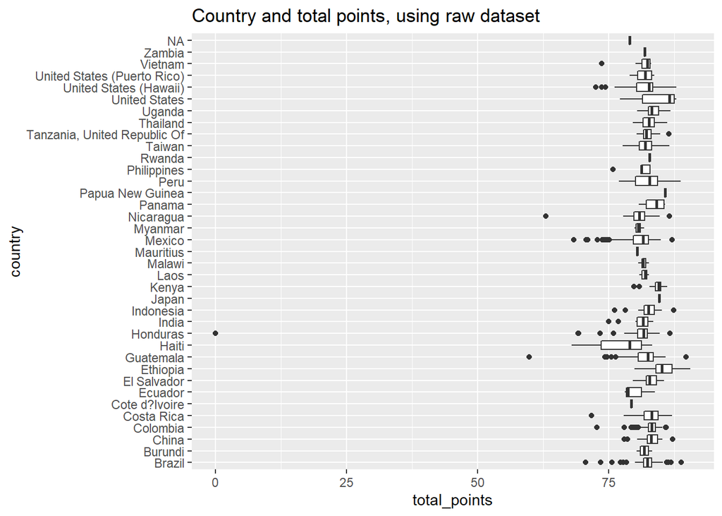

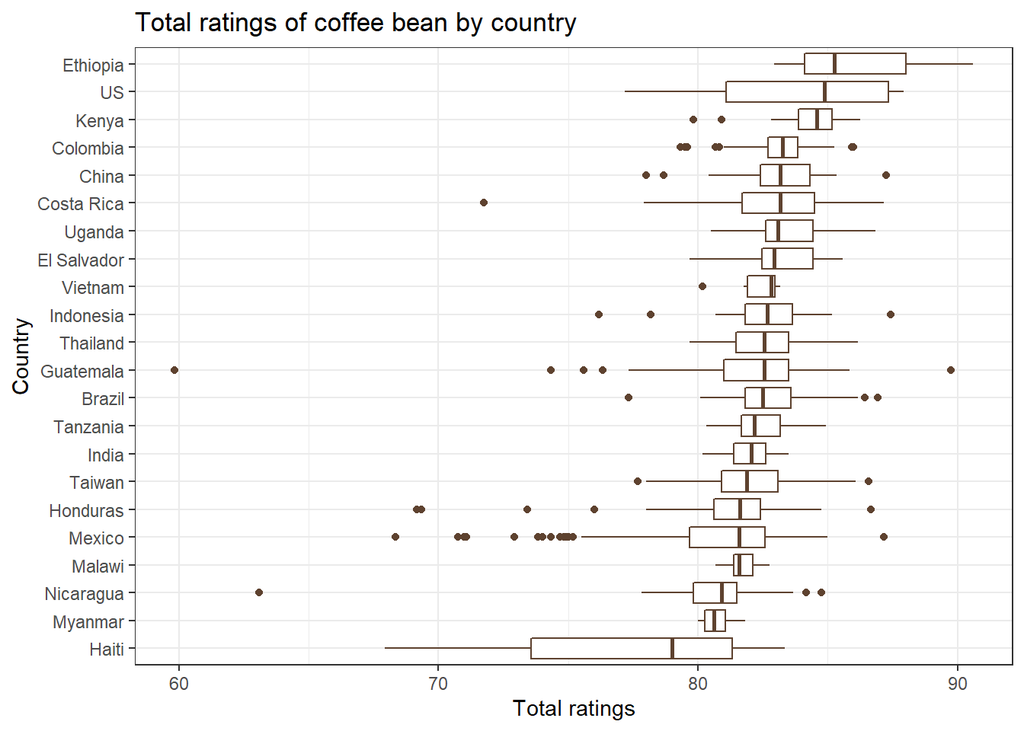

Figure 4.1: Boxplot for total ratings of coffee beans of countries with at least 5 coffee samples.

Figure 4.1 aims to address the primary question **Which country produces best quality coffee beans?**. The X-axis shows the overall rating achieved by the coffee bean while the Y-axis denotes the country where it was produced.

Ethiopia produced the highest quality of coffee beans. However, it is interesting to note that there is not much variation between countries as most of them have median scores of around 80-85 points. Thus, we can conclude based on the dataset, that there is not much difference in coffee quality between countries, with Ethiopia produces the highest-quality beans.

##### 4.3.3.1.2 Does altitude affect the quality of coffee beans?

Now, we want to see the relationship between altitude and the quality of coffee beans. In other words, we want to compare 2 numeric variables. Scatterplot is the perfect tool for this job. From Data-to-viz:  
A scatterplot displays the relationship between 2 numeric variables. For each data point, the value of its first variable is represented on the X axis, the second on the Y axis

- For scatter plot, over plotting is the most common mistake when sample size is high. Consider decrease dot size, or modify transparency.
- Don’t forget to show subgroups if you have some. If there are too many countries, how about categorize them by continent?

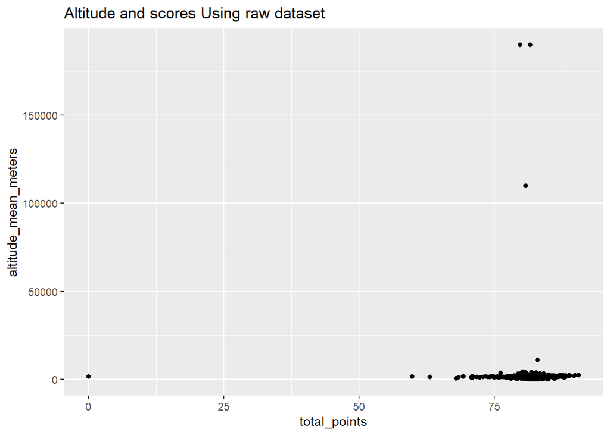

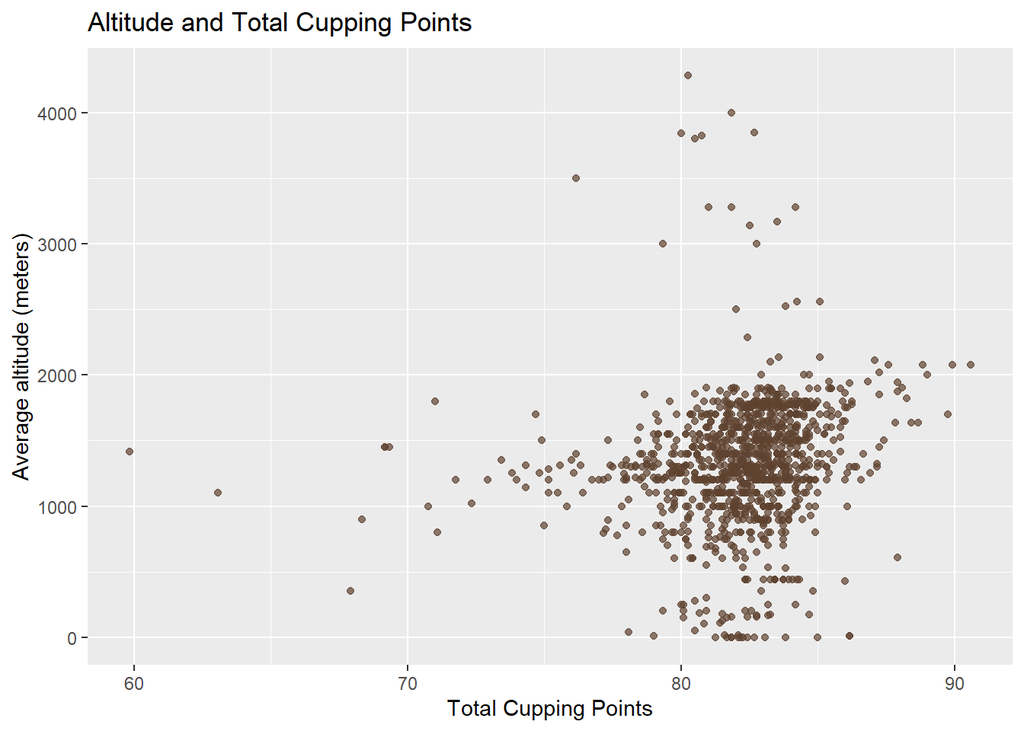

Figure 4.2: Altitude and Total cup points scatter plot

From 4.2, we can see that there is no noticeable trend in total cup points and height. It is also interesting to note that the majority of coffee samples were grown 750-2000m above sea levels. Also, most coffee beans seem to score very high, around 80-85 points.

##### 4.3.3.1.3 What are the trends in grading date?

While waiting for his lovely cup of coffee to brew, the author happened to read a interesting research Danziger, Levav, and Avnaim-Pesso (2011) that has found correlation between a parole case’s success rate and whether the case was heard right before or after lunch. The idea is that judges might be more exhausted before lunch, which would make them stricter. Enlightened, he wanted to see if there is anything similar happen in coffee grading. Are graders stricter on Friday compared to Monday?

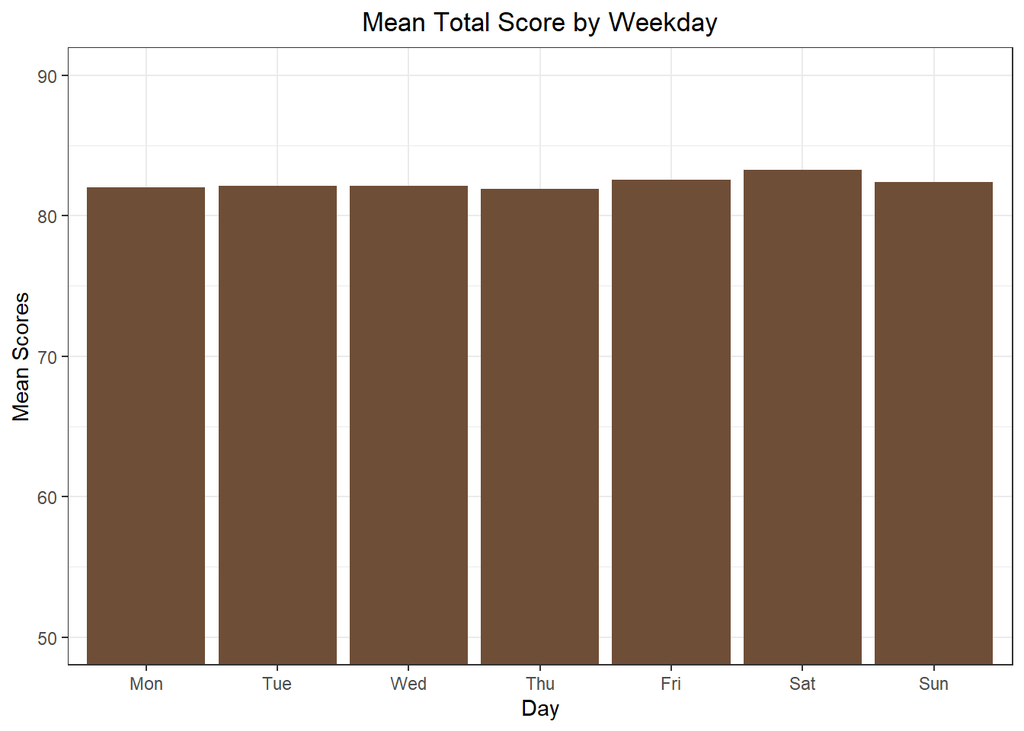

Figure 4.3: Mean total cup scores by week day. The average point stay stable throughout the week

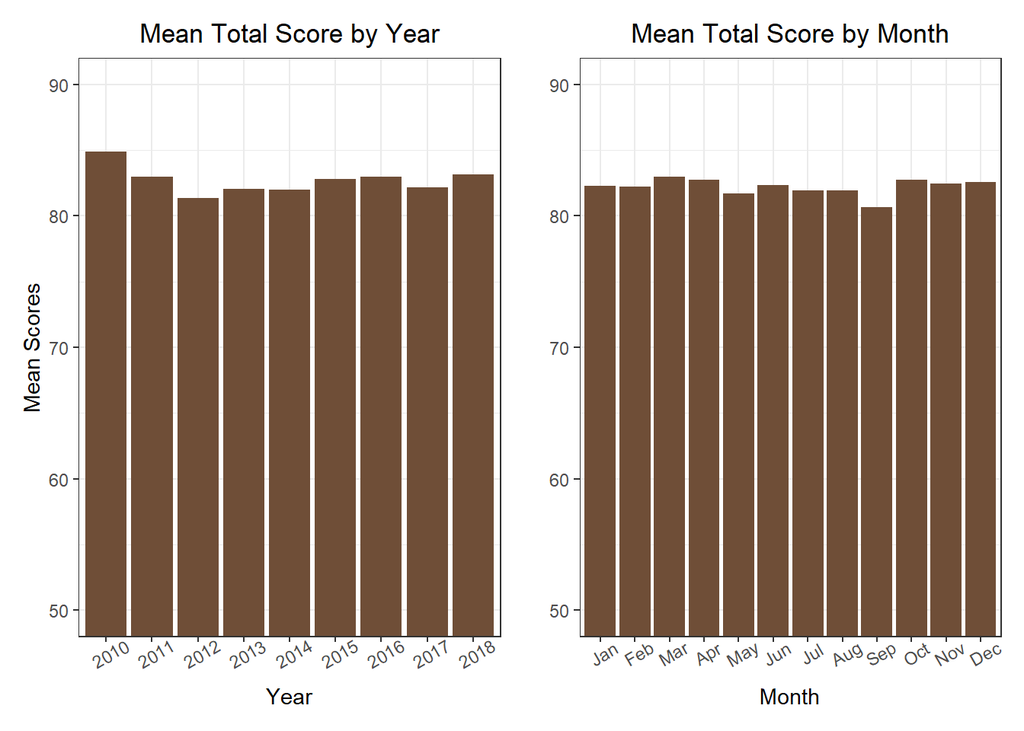

Figure 4.4: Mean total cup score per grading year and month

**The answer seems to be No.**

From figure 4.3, it seems that coffee graders seem to be consistent with their grading across the weeks.

But, does this trend stay true across years and months? Figure 4.4 answer that question. The figure suggest that the score remain stable throughout months and years.

From the previous findings, the researchers conclude that coffee graders seem to be consistent with their grading across years, months and days of the week. On that ground, it is safe to say that coffee seems to be consistent in quality throughout the years.

##### 4.3.3.1.4 What is the impact of different processing method on individual grading criteria?

Here, I chose 6 grading criteria based on the coffee scoring article provided on “Scoring Coffee” (2020):

- Aroma
- Aftertaste
- Flavor
- Acidity
- Body
- Balance

Because we wanted to explore 6 variables, scatter plot to compare them pair-wise is my idea. However, it is tiresome creating each plot one by one. Therefore, I utilized ggscatmat function from GGally. the function will create scatterplot matrix for quantitative variables with density plots on the diagonal and correlation printed in the upper triangle.

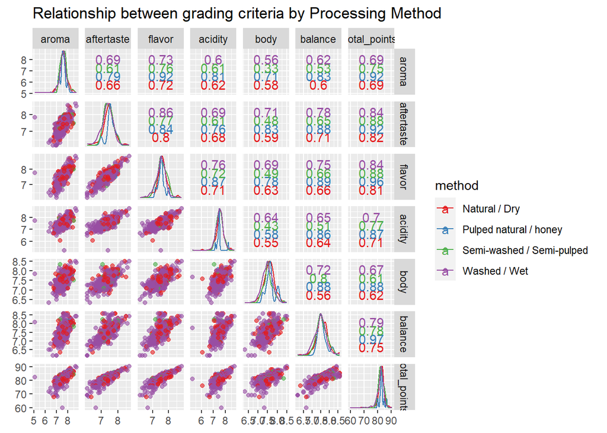

Figure 4.5: Scatterplot matrix of grading criterias, differentiated by processing method

The scatter plot matrix examines the relationship between each grading criteria, with different color represent different methods of processing

Overall, based on the density plots (plots on diagonal line), most processing method seems to generate similar results. Furthermore, the primary processing method are “Washed/Wet” and “Natural/Dry” across all coffee bean producers.We can barely capture the appearance of other two methods. The method “Pulped natural/honey” have relatively low density compared to other. It also has different distribution.

#### 4.3.3.2 Limitations and suggestions for future research

The report has potential limitations: There is a lack of available and reliable data. The measurement unit is not united. For example, altitude was measured in both feet and meters. Moreover, the sample size is small, and differ largely from country to country, with some countries have hundreds of observations while others have only one or two observations.

The dataset is outdated (it was collected in 2018), with several missing values in critical variables (i.e processing method, region, producers, etc.). They are obstacles for the researchers to find meaningful trends and relationships.

Thus, it is recommended for future researchers to use a larger, more accurate and well-rounded dataset to perform their study.

#### 4.3.3.3 Conclusion

# 5 Acknowledgement

Following R packages are used in producing this research:

- rmarkdown: Xie, Allaire, and Grolemund (2018)
- tidyverse: Wickham et al. (2019)
- kableExtra: Zhu (2019)
- ggplot2: Wickham (2016)
- bookdown: Xie (2016)
- wordcloud: Fellows (2018)
- wordcloud2: Lang and Chien (2018)
- lubridate: Grolemund and Wickham (2011)
- tidytext: Silge and Robinson (2016)
- tidymodels: Kuhn and Wickham (2020)
- naniar: Tierney et al. (2021)
- patchwork: Pedersen (2020)
- gutenbergr: Robinson (2021)

# References

Danziger, Shai, Jonathan Levav, and Liora Avnaim-Pesso. 2011. “Extraneous Factors in Judicial Decisions,” April. https://doi.org/doi: 10.1073/pnas.1018033108.

Fellows, Ian. 2018. *Wordcloud: Word Clouds*. https://CRAN.R-project.org/package=wordcloud.

Grolemund, Garrett, and Hadley Wickham. 2011. “Dates and Times Made Easy with lubridate.” *Journal of Statistical Software* 40 (3): 1–25. http://www.jstatsoft.org/v40/i03/.

ICQ. 2020. “Grade Details, q Arabica q Arabica Certificate.” https://database.coffeeinstitute.org/coffee/357789/grade.

Kuhn, Max, and Hadley Wickham. 2020. *Tidymodels: A Collection of Packages for Modeling and Machine Learning Using Tidyverse Principles.* https://www.tidymodels.org.

Lang, Dawei, and Guan-tin Chien. 2018. *Wordcloud2: Create Word Cloud by ’Htmlwidget’*. https://CRAN.R-project.org/package=wordcloud2.

LeDoux, James. 2018. “Coffee Quality Database.” *GitHub Repository*. https://github.com/jldbc/coffee-quality-database.

Mock, Thomas. 2020. “R for Data Science.” *GitHub Repository*. https://github.com/rfordatascience/tidytuesday/blob/master/data/2020/2020-07-07/readme.md.

Pedersen, Thomas Lin. 2020. *Patchwork: The Composer of Plots*. https://CRAN.R-project.org/package=patchwork.

Robinson, David. 2021. *Gutenbergr: Download and Process Public Domain Works from Project Gutenberg*. https://CRAN.R-project.org/package=gutenbergr.

“Scoring Coffee.” 2020. *My Cuppa*. https://www.mycuppa.com.au/scoring-coffee.

Silge, Julia, and David Robinson. 2016. “Tidytext: Text Mining and Analysis Using Tidy Data Principles in r.” *JOSS* 1 (3). https://doi.org/10.21105/joss.00037.

Tierney, Nicholas, Di Cook, Miles McBain, and Colin Fay. 2021. *Naniar: Data Structures, Summaries, and Visualisations for Missing Data*. https://CRAN.R-project.org/package=naniar.

Wickham, Hadley. 2016. *Ggplot2: Elegant Graphics for Data Analysis*. Springer-Verlag New York. https://ggplot2.tidyverse.org.

Wickham, Hadley, Mara Averick, Jennifer Bryan, Winston Chang, Lucy D’Agostino McGowan, Romain François, Garrett Grolemund, et al. 2019. “Welcome to the tidyverse.” *Journal of Open Source Software* 4 (43): 1686. https://doi.org/10.21105/joss.01686.

Xie, Yihui. 2016. *Bookdown: Authoring Books and Technical Documents with R Markdown*. Boca Raton, Florida: Chapman; Hall/CRC. https://github.com/rstudio/bookdown.

Xie, Yihui, J. J. Allaire, and Garrett Grolemund. 2018. *R Markdown: The Definitive Guide*. Boca Raton, Florida: Chapman; Hall/CRC. https://bookdown.org/yihui/rmarkdown.

Zhu, Hao. 2019. *kableExtra: Construct Complex Table with ’Kable’ and Pipe Syntax*. https://CRAN.R-project.org/package=kableExtra.